# Panel Data and Fixed Effects

EC 325: Econometrics

Prof. Caraher

Colby College

2026-11-11

## Where We Are

- The **Fundamental Problem of Causal Inference**
  - Cannot observe both the treated and untreated outcome for unit $i$ – no multiverse!
  - Need to control for **Selection Bias** to ensure **apples-to-apples** comparisons
- Best method: the “gold standard” of the **RCT**
  - Random assignment ensures comparable treatment and control groups
- Next best alternative: **multivariate OLS**
  - Control directly for omitted variables which may cause selection bias
  - More flexible with dummy variables, non-linear variables, interactions, etc.
- We can control for what we can observe… but what about **unobservable** confounders? Ability, motivation, culture, history?

Today: a new data structure — **panel data** — that lets us control for (certain) unobservables.

## Cross-Sectional Data

Most datasets we’ve looked at so far have been **cross-sectional**: units observed at a single point in time.

- Wages and education data from the 2024 ACS
- Health outcomes in the Oregon Health Insurance Experiment
- Women’s labor force participation

We can describe a population, identify correlations, and control for observable confounders. But there’s a big limitation…

## What Cross-Sectional Data Struggles With

- Say we run the following regression: $crime = \beta_0 + \beta_1(unem) + \mu$

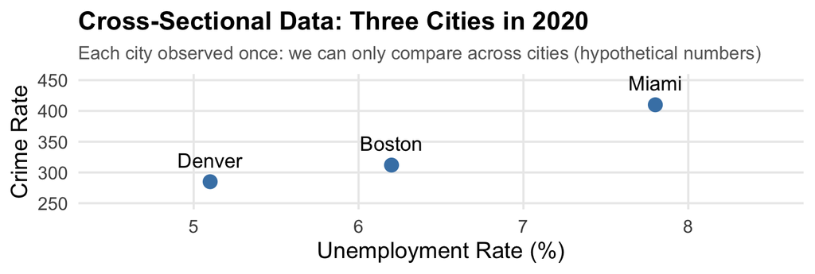

- OLS uses the variation in $x$ and $y$ between cities to generate an estimate, $\hat{\beta}_1$.
- But notice: Miami has high unemployment **and** high crime. But is that because unemployment *causes* crime, or because Miami differs in many unobserved ways (geography, culture, history)?
- The implication for OLS: Miami’s unobserved traits sit in $\mu$. If they’re correlated with unemployment, $E[\mu | unem] \neq 0$ (GM4 fails), so $\hat{\beta}_1$ is **biased**: it mixes the effect of unemployment with everything else that makes Miami different.

We can’t control for what we can’t measure!

## Panel Data

This is in contrast to **panel data**: the same units observed at *multiple points in time*.

- NBA players observed across multiple seasons
- Employment and minimum wages in states across multiple quarters
- Pre-period and post-period data in an experiment
- Stock prices for multiple companies tracked daily for a year

| Example | Unit ($i$) | Time ($t$) |
| --- | --- | --- |
| Workers tracked annually | Person | Year |
| States observed quarterly | State | Quarter |
| Firms reported monthly | Firm | Month |
| Countries measured yearly | Country | Year |

## What If We Followed Cities Over Time?

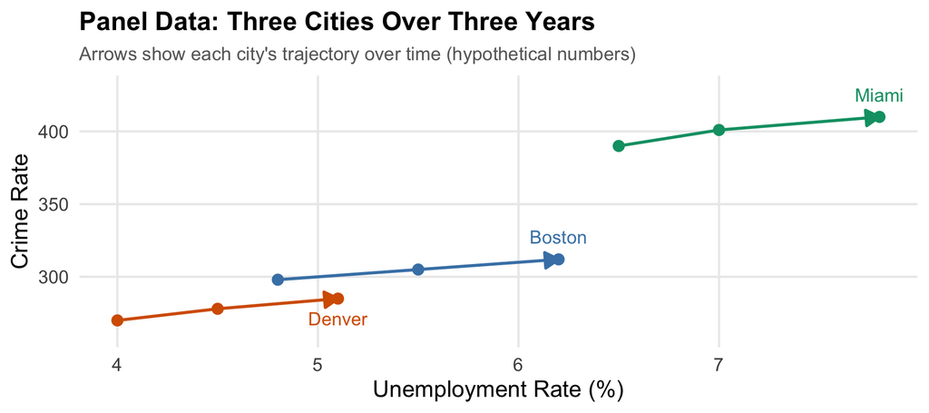

- Now we can ask: when unemployment rises **within a given city**, does crime rise too?

## The Key Insight

Panel data lets us control for **all time-invariant characteristics** of each unit — whether observed or unobserved — by using only **within-unit** variation to estimate the relationship between $x$ and $y$.

- **Between** variation: comparing *different* cities to each other (confounded by all ways cities differ)
- **Within** variation: comparing *each city to itself* over time (stable city-level confounders cancel out)

The question shifts from “do cities with more unemployment have more crime?” to “when unemployment rises *within a city*, does crime rise too?”

Panel data also lets us study how outcomes change over time, which we’ll use for DiD and event studies in Units 12–13.

## The Fixed Effects Model

We formalize this with the **fixed effects model**:

$$y_{it} = \beta_0 + \beta_1 x_{it} + a_i + \mu_{it}$$

- $y_{it}$: outcome for unit $i$ at time $t$
- $x_{it}$: explanatory variable (varies across units **and** time)
- $a_i$: **unit fixed effect** — captures all time-invariant characteristics of unit $i$: a city’s location, historical legacy, stable institutions, “culture,” and other hard-to-measure factors
- $\mu_{it}$: idiosyncratic error (the leftover)

If we ignore $a_i$, it ends up in the error term, so OLS suffers from **OVB** whenever $x_{it}$ is correlated with $a_i$.

We don’t need to **observe** these things. We don’t need to **measure** them. We just need them to be **stable** over the time periods we observe.

## How Does It Work? The Within Transformation

We can’t observe $a_i$ directly. But we can **eliminate** it.

**Step 1:** For each unit $i$, compute the time average of every variable:

$$\bar{y}_i = \beta_0 + \beta_1 \bar{x}_i + a_i + \bar{\mu}_i$$

**Step 2:** Subtract the time-average equation from the original:

$$y_{it} - \bar{y}_i = (\beta_0 - \beta_0) + \beta_1(x_{it} - \bar{x}_i) + (a_i - a_i) + (\mu_{it} - \bar{\mu}_i)$$

Since $a_i$ is constant over time, its time average is just itself, so $a_i - a_i = 0$: **the fixed effect drops out!** The intercept drops out too. We’re left with only **demeaned** variables:

$$\ddot{y}_{it} = \beta_1 \ddot{x}_{it} + \ddot{\mu}_{it}$$

The only variation left is how each unit **differs from its own average** over time, so $\beta_1$ is identified purely from **within-unit changes**.

## Example: Unemployment and Crime

Back to our question with **simulated data**: `crime_data` has **40 cities** observed for **6 years**. Because we built the data, we know the true effect and can check each method against it at the end.

Let’s start with a **cross-sectional** regression using just year 6:

```r
reg_cross <- feols(crime ~ unem, data = filter(crime_data, year == 6), vcov = "HC1")
coef(reg_cross)
```

```
(Intercept)        unem
  85.411246   -3.136507
```

The coefficient on `unem` is **negative**: higher unemployment $\rightarrow$ *less* crime?

This makes no intuitive sense. Almost certainly **OVB** — big, dense cities have strong job markets (low unemployment) but also more crime.

Density raises crime (+) and lowers unemployment (−), so the bias is (+) × (−) = **negative**.

## Now Layer in the Panel Structure

Same cities, but now we connect observations **within** each city over time:

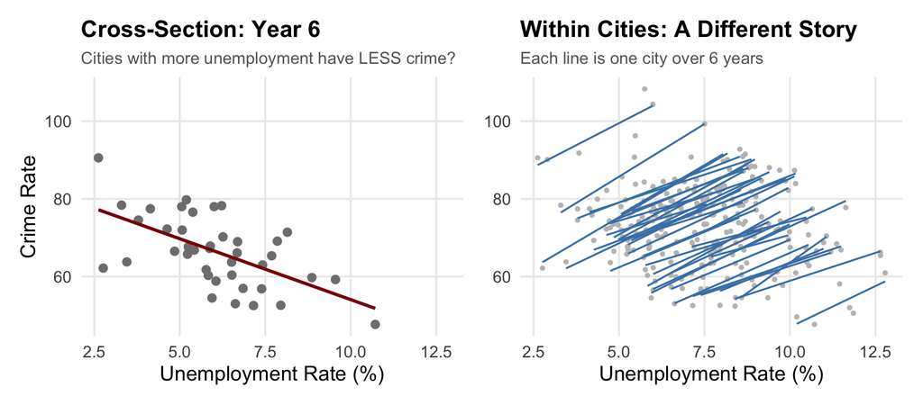

The **within-city** slopes tell the opposite story from the cross-sectional one!

## The Within Transformation by Hand

Let’s apply the two steps to `crime_data`. **Step 1:** demean by city. **Step 2:** regress the demeaned variables:

```r
crime_dm <- crime_data |>
  group_by(city) |>
  mutate(unem_demean = unem - mean(unem),
         crime_demean = crime - mean(crime)) |>
  ungroup()

lm(crime_demean ~ unem_demean, data = crime_dm) |> coef() |> round(3)
```

```
(Intercept) unem_demean
      0.000       3.795
```

- **Positive:** subtracting each city’s average removes stable traits like density, so the sign flips from the cross-section’s -3.14.
- 3.80 is a weighted average of the 40 blue lines in the last plot: each city’s own slope, with cities whose unemployment moved more counting more.

## Going Further: Time Fixed Effects

- Demeaning by city removed stable, **unit-specific** confounders
- But what about shocks that hit **all** cities in a given year (e.g., a recession, a national policy change)?
- We control for these with **time fixed effects**.
- In our data, crime fell, partly for reasons unrelated to unemployment such as overall reduction from the crime waves in the 1990s. Demeaning by city alone credits unemployment with that shared trend!
- So we demean again, subtracting **year-specific across-city averages**:

```r
crime_dm <- crime_dm |>
  group_by(year) |>
  mutate(unem_demean2 = unem_demean - mean(unem_demean),
         crime_demean2 = crime_demean - mean(crime_demean)) |>
  ungroup()

lm(crime_demean2 ~ unem_demean2, data = crime_dm) |> coef() |> round(3)
```

```
 (Intercept) unem_demean2
       0.000        2.832
```

Demeaning first by unit, then by time adds **both** unit and time fixed effects (in a balanced panel, where every unit appears in every period). Here the estimate falls from 3.80 to 2.83.

## Equivalently: Dummy Variable Regression

Instead of demeaning, we can estimate the same model with **dummy variable regression**:

$$y_{it} = \beta_0 + \beta_1 x_{it} + a_i + \tau_t + \mu_{it}$$

Include a **dummy variable for each unit** $i$ (minus one omitted category) and a **dummy variable for each time** $t$ (minus one omitted period)

- Sometimes we **drop the intercept** instead and keep a dummy for **every** unit (one time period is still omitted). Each unit’s dummy is then its own baseline, not a difference from the omitted unit

In R, `feols()` does this **much faster**. Fixed effects go after a vertical bar `|`:

```r
reg_fe <- feols(crime ~ unem | city + year, data = crime_data, vcov = "HC1")
coef(reg_fe)
```

```
    unem
2.831529
```

- **Left of `|`:** standard regression formula — variables you want coefficients for
- **Right of `|`:** fixed effects (absorbed) — **not** reported, but `fixef()` retrieves them
- `vcov = "HC1"`: robust SEs, as in Units 9–10 (Unit 13 adds clustered SEs)

## Side-by-Side Results

```r
reg_city <- feols(crime ~ unem | city, data = crime_data, vcov = "HC1")

results_table <- modelsummary(list("Cross-Section" = reg_cross,
                                   "City FE" = reg_city,
                                   "City + Year FE" = reg_fe),
                              coef_omit = "Intercept",
                              gof_map = "nobs",
                              add_rows = tribble(
                                  ~term, ~`Cross-Section`, ~`City FE`, ~`City + Year FE`,
                                  "City FE", "No", "Yes", "Yes",
                                  "Year FE", "No", "No", "Yes"
                              ))
```

|  | Cross-Section | City FE | City + Year FE |
| --- | --- | --- | --- |
| unem | -3.137 | 3.795 | 2.832 |
|  | (0.761) | (0.133) | (0.233) |
| Num.Obs. | 40 | 240 | 240 |
| City FE | No | Yes | Yes |
| Year FE | No | No | Yes |

- **City FE** flip the sign: they remove the bias from stable city traits like density.
- **Year FE** then remove the shared national trend.
- Both FE columns match our demeaning by hand exactly.
- Researchers report fixed effects as “Yes/No” rows rather than every dummy coefficient.

## Interpreting Fixed Effects Coefficients (1/2)

- Fixed effects are just dummy variables, so how can we interpret the coefficients on the dummy variables for each city and year?

-`fixef()` retrieves the fixed effects themselves. Start with the city FE:

```r
fe_estimates <- fixef(reg_fe)
round(fe_estimates$city[1:4], 2)
```

```
    1     2     3     4
48.19 42.48 33.31 44.95
```

- `feols()` has no intercept, so it keeps a FE for **every** city. Alone, 48.19 is city 1’s predicted crime rate in year 1 at 0% unemployment, which isn’t a useful number.
- **Compare cities instead:** at the same unemployment rate in the same year, city 1’s crime rate is 5.70 higher than city 2’s.
- That gap reflects everything stable about the two cities. Here it’s mostly **density**, the confounder we left out of the regression.

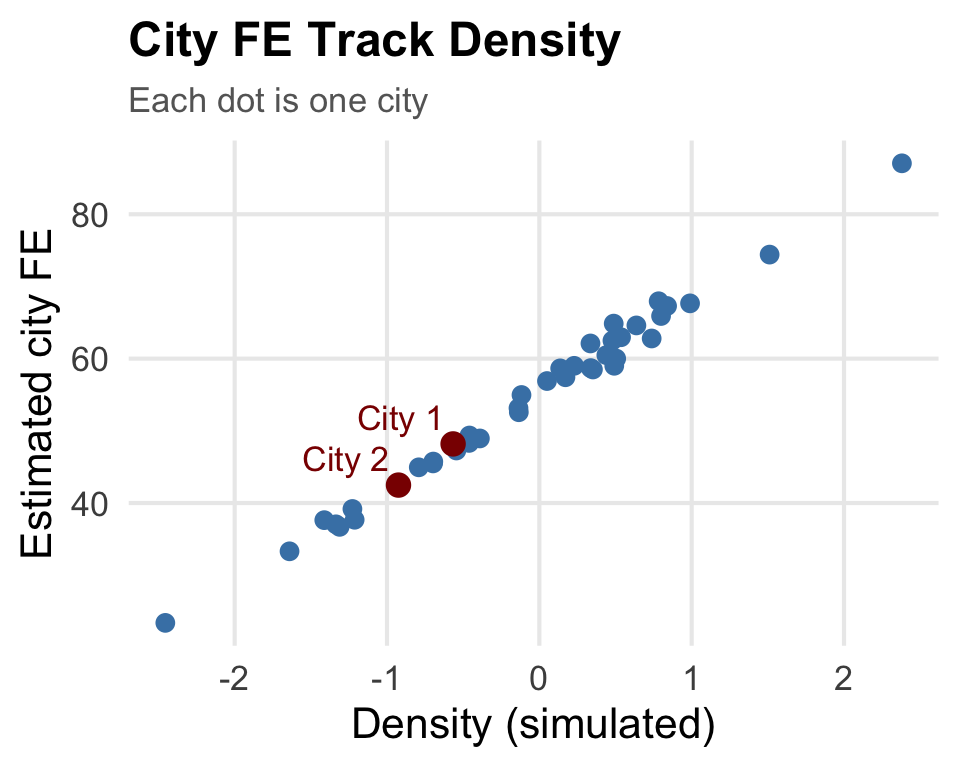

## Interpreting Fixed Effects Coefficients (2/2)

Now the year FE:

```r
round(fe_estimates$year, 2)
```

```
    1     2     3     4     5     6
 0.00 -1.61 -2.16 -3.40 -4.09 -4.92
```

- **Year 1 is the reference**, so it’s 0: `feols()` drops one year to avoid the dummy variable trap.
- **Year 6 is -4.92:** at the same unemployment rate, a city’s crime rate is 4.92 lower than in year 1.

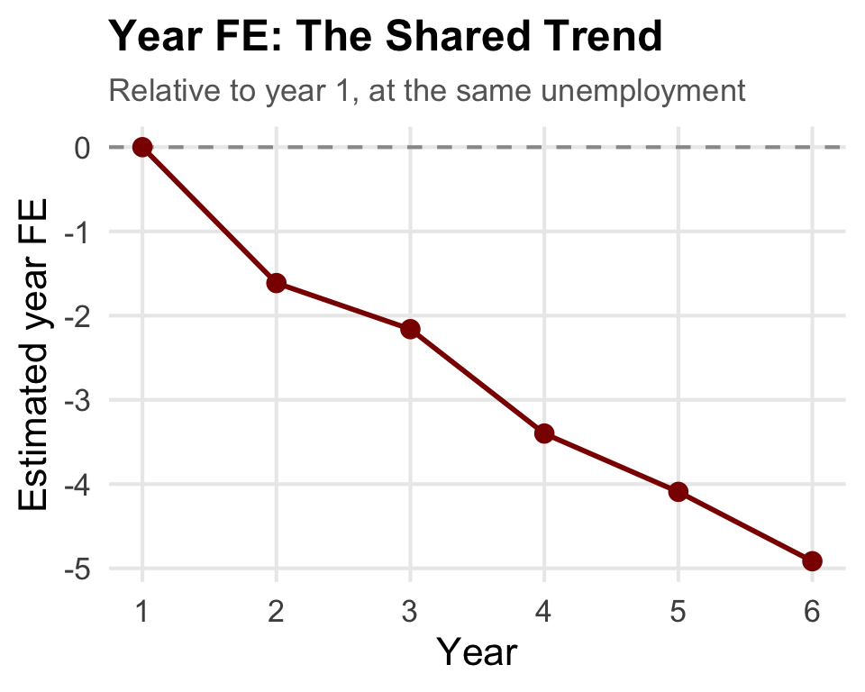

We usually don’t care about the coefficients on the fixed effects *per se*: they absorb confounders so we can estimate $\beta_1$.

## What Do FE Control For?

**Unit FE** control for anything specific to a unit that is **constant over time**: geography, historical legacy, stable institutions, baseline demographics, measurement differences, culture.

**Time FE** control for anything that hits **all units equally** in a given period: macroeconomic shocks, national policy changes, seasonal patterns, technology trends.

**Neither** controls for factors that vary **both across units and over time** — for example, a city-specific economic boom or a policy change that only affects some cities. These are **unit-specific, time-varying confounders** and must be controlled for explicitly (or remain a source of potential bias if unobserved).

## A Classification Exercise

For each confounder, is it absorbed by unit FE, time FE, or neither?

- A city’s geographic terrain? **Unit FE** — constant across time for a given city
- Nationwide sentencing reform? **Time FE** — if it hits all cities equally in that period
- City-specific economic boom in 2019? **Neither** — varies across cities *and* over time
- A city-specific policing strategy introduced in 2019? **Neither** — unit-specific and time-varying
- A national recession that hits manufacturing cities hardest? **Only partly:** time FE absorb the national average, but not the extra hit to manufacturing cities

The “neither” cases are **unit-specific, time-varying confounders**. These require explicit control variables.

## Adding Time-Varying Controls

- One way to address the fact that FEs don’t account for **unit-specific, time-varying confounders** is to directly control for them!
- In `feols()`, they go on the **left** side of `|`, like any other variable
- Of course, this requires that you can observe these variables, so it’s only a partial solution

$$y_{it} = \beta_1 x_{it} + \gamma z_{it} + a_i + \tau_t + \mu_{it}$$

In our data, a higher share of residents ages 15–24 (`pct_young`) raises unemployment *and* crime:

```r
reg_ctrl <- feols(crime ~ unem + pct_young | city + year, data = crime_data, vcov = "HC1")
```

|  | No Control | With pct_young |
| --- | --- | --- |
| unem | 2.832 | 2.094 |
|  | (0.233) | (0.232) |
| pct_young |  | 1.448 |
|  |  | (0.201) |

We built these data with a true effect of **2**:

- Cross-section: -3.14
- City FE: 3.80
- City + year FE: 2.83
- City + year FE + control: 2.09

## Other Kinds of Fixed Effects

- While unit and time FEs are the most common, it is not unusual to see more complicated fixed effects
- In general, a group-specific fixed effect will absorb all confounders common to that group, so $\hat{\beta}_1$ comes only from comparisons **within** the fixed effect groups.
- We can also use a dummy to include other types of FEs

| Fixed effect | Absorbs | $\hat{\beta}_1$ compares cities… |
| --- | --- | --- |
| City | stable city traits | …to themselves over time |
| Year | national shocks | …in the same year |
| Region × year | a shock to one region in one year | …in the same region and year |
| City × post-COVID | each city’s own shift after 2020 | …to themselves, separately pre- and post-COVID |

In `feols()`, `^` combines two variables into one FE. Suppose our 40 cities fall into 4 regions:

```r
crime_regions <- crime_data |>
  mutate(region = ceiling(city / 10))  # 4 regions of 10 cities

reg_region <- feols(crime ~ unem | city + region^year, data = crime_regions, vcov = "HC1")
coef(reg_region)
```

```
    unem
2.882983
```

**Interpretation:** when a city’s unemployment rises 1 point more than its regional neighbors’ in the same year, its crime rate rises about 2.88 more

## Caveats: More Fixed Effects Aren’t Free

- However, it is important to be very careful when going beyong unit and time fixed effects. This is because:
- **You need a lot of data and variation within groups.** Each FE group needs several observations whose $x$ moves differently. Treat years 4–6 as “post-COVID”: city × post FE add 40 parameters, and the SE on `unem` rises from 0.23 to 0.27.
- **A FE can’t single out one observation.** With city × year FE, every observation is alone in its group, so its FE fits it perfectly and nothing is left to estimate $\beta_1$:

```r
feols(crime ~ unem | city^year, data = crime_data)
```

```
Error: in feols(crime ~ unem | city^year, data = crime_data):
All observations are fixed-effects singletons. The estimation cannot be
done.
```

- The same happens on a smaller scale: a region with only one city (under region × year FE), or a post period with only one year (under city × post FE), contributes **nothing** to $\hat{\beta}_1$.
- **A FE can absorb your $x$.** If $x$ only varies at the level of a FE (e.g., a region-wide policy with region × year FE), it’s collinear with the FE and can’t be estimated.
- **More FE $\neq$ causal.** Each new FE narrows the question $\hat{\beta}_1$ answers. Confounders that vary *within* the finest groups, and reverse causality, still bias it.

## When Are Fixed Effects Most Useful?

**Good fit for FE:**

- Genuine panel data (same units, multiple periods)
- Meaningful within-unit variation in $x$
- Time-invariant confounders are a primary concern

**Less useful when:**

- Little within-unit variation (everyone’s $x$ is stable over time)
- Unobserved unit-specific, time-varying confounders are a main concern

## Summary

1. **Panel data**: same units observed over multiple time periods
2. The **within transformation** eliminates all time-invariant confounders by demeaning
3. **Unit FE** absorb permanent unit characteristics (observed and unobserved)
4. **Time FE** absorb shocks common to all units in a given period
5. In R: `feols(y ~ x | unit + time, data = mydata, vcov = "HC1")`
6. Can add **time-varying controls** on the left side of `|`
7. **Cannot** control for unit-specific, time-varying confounding variables

Fixed effects $\neq$ no OVB. Unit-specific, time-varying confounders can still bias results. But FE is a **major improvement** over cross-sectional analysis when time-invariant confounders are the primary concern.